# Stable Isotope Mixing Models for Dietary Reconstruction

Module 2 · Understanding Mixing Models · 09:30–10:30

Author

Archaeological Isotope Laboratory

Published

18 February 2026

One-Day Training Programme | Morning Session 09:30–10:30

# 1 Understanding Mixing Models

This module introduces the mathematical and conceptual frameworks that underpin stable isotope mixing models, with particular focus on **ReSources** (Fernandes et al. 2021) — a state-of-the-art Bayesian routed mixing model designed specifically for archaeological bone collagen analysis.

By the end of this hour you should be able to:

- Distinguish simple linear mixing models from Bayesian routed approaches
- Explain why isotopic routing matters for collagen-based dietary reconstruction
- Write down and interpret the fundamental mixing model equations
- Understand the ReSources workflow and its advantages over unrouted models
- Critically evaluate mixing model outputs in light of their assumptions and limitations
- Recognise isotopic overlap and equifinality as fundamental interpretive challenges

# 2 Linear Mixing Models vs. Bayesian Routed Approaches

## 2.1 The Fundamental Problem

All stable isotope mixing models attempt to solve the same inverse problem: given a consumer’s tissue isotope values and the isotope values of potential dietary sources, what proportions of each source were consumed?

However, the approaches differ fundamentally in:

1. **How they handle uncertainty** (point estimates vs. probability distributions)
2. **Whether they model isotopic routing** (bulk diet vs. tissue-specific routing)
3. **Computational methodology** (algebraic vs. Markov Chain Monte Carlo)

## 2.2 Three Generations of Mixing Models

### 2.2.1 Generation 1: Simple Linear Models (1980s–2000s)

**Philosophy:** Solve algebraic equations assuming all dietary components contribute equally to tissue.

**Examples:** Hand calculations, IsoSource (Phillips & Gregg 2001)

**Strengths:**  
✓ Transparent algebra  
✓ Fast computation  
✓ Good for teaching fundamentals

**Critical limitation:** Assumes bone collagen reflects **bulk diet** isotope values, ignoring the fact that collagen is synthesised preferentially from dietary protein.

### 2.2.2 Generation 2: Bayesian Unrouted Models (2008–2015)

**Philosophy:** Use Bayesian inference to estimate probability distributions over all possible source contributions, formally propagating uncertainty.

**Examples:** SIAR (Parnell et al. 2010), early MixSIAR

**Strengths:**  
✓ Formal uncertainty quantification  
✓ Can incorporate prior information  
✓ Handles complex error structures

**Critical limitation:** Still assumes bulk diet mixing — **does not account for selective routing of dietary protein to collagen**.

### 2.2.3 Generation 3: Bayesian Routed Models (2014–present)

**Philosophy:** Explicitly model the differential routing of dietary **protein** vs. **energy** (carbohydrates/lipids) to bone collagen.

**Examples:** FRUITS (Fernandes et al. 2014), **ReSources** (Fernandes et al. 2021), IsotopeR

**Why routing matters**

A population consuming 70% maize (C<sub>4</sub>) by energy but only 20% animal protein will have bone collagen δ<sup>13</sup>C closer to the **animal protein value** than to the maize value, because collagen is synthesised from amino acids sourced preferentially from dietary protein.

**Unrouted models** (SIAR, early MixSIAR) would incorrectly infer ~70% C<sub>4</sub> diet. **Routed models** (ReSources, FRUITS) correctly reconstruct the protein vs. energy balance.

# 3 ReSources: A Bayesian Routed Mixing Model

## 3.1 Overview and Philosophy

**ReSources** (Fernandes et al. 2021, *Science Advances* DOI: 10.1126/sciadv.abg5791) is a Bayesian mixing model that explicitly accounts for the selective routing of dietary macronutrients to bone collagen.

### 3.1.1 Key Features

Table 1: ReSources key characteristics

| Feature | Description |
| --- | --- |
| **Framework** | Bayesian inference via JAGS (Just Another Gibbs Sampler) |
| **Routing** | Separates protein vs. energy routing to collagen |
| **Uncertainty** | Full posterior distributions for all dietary proportions |
| **Priors** | Flexible: uninformative, weakly informative, or strongly informative |
| **Interface** | R package with GUI; also command-line scripting |
| **Target tissue** | Bone/dentine collagen (designed for archaeological applications) |
| **Computational efficiency** | Faster convergence than FRUITS; suitable for large datasets |

### 3.1.2 Installation and Setup

ReSources is distributed as an R package. Installation requires:

```r
# Install from GitHub (requires devtools)
install.packages("devtools")
devtools::install_github("EISALab/ReSources")

# Load the package
library(ReSources)

# Launch GUI (optional)
ReSources_GUI()
```

**System requirements**

- R ≥ 4.0
- JAGS ≥ 4.3 (standalone software; install from https://mcmc-jags.sourceforge.io/)
- For large datasets (n > 100 consumers), 8+ GB RAM recommended

# 4 The Routed Mixing Model Equation

## 4.1 Conceptual Framework

ReSources models bone collagen isotope values as a function of:

1. **Dietary protein sources** — contribute disproportionately to collagen carbon
2. **Dietary energy sources** — contribute minimally to collagen carbon but dominate total caloric intake
3. **Trophic enrichment factors** — applied separately for protein-routed vs. energy-routed carbon

### 4.1.1 The Routed Carbon Equation

For bone collagen δ<sup>13</sup>C:

$$\delta^{13}C_{\text{collagen}} = \lambda \cdot \left[ \sum_{i=1}^{n_p} p_i \cdot (\delta^{13}C_{i,\text{protein}} + \Delta^{13}C_p) \right] + (1 - \lambda) \cdot \left[ \sum_{j=1}^{n_e} e_j \cdot (\delta^{13}C_{j,\text{energy}} + \Delta^{13}C_e) \right]
\tag{1}$$

Where:

- $\lambda$ = **routing parameter** (proportion of collagen C from dietary protein; typically 0.70–0.85)
- $p_i$ = proportional contribution of protein source $i$ to total dietary protein (∑ $p_i$ = 1)
- $e_j$ = proportional contribution of energy source $j$ to total dietary energy (∑ $e_j$ = 1)
- $\delta^{13}C_{i,\text{protein}}$ = carbon isotope value of protein source $i$
- $\delta^{13}C_{j,\text{energy}}$ = carbon isotope value of energy source $j$ (e.g., cereals, tubers)
- $\Delta^{13}C_p, \Delta^{13}C_e$ = trophic enrichment factors for protein-routed and energy-routed carbon

### 4.1.2 The Nitrogen Equation (Unrouted)

For bone collagen δ<sup>15</sup>N, routing is less critical because nitrogen is overwhelmingly sourced from dietary protein:

$$\delta^{15}N_{\text{collagen}} = \sum_{i=1}^{n_p} p_i \cdot (\delta^{15}N_{i,\text{protein}} + \Delta^{15}N)
\tag{2}$$

Where $\Delta^{15}N$ is the trophic enrichment factor for nitrogen (typically +3.0 to +5.0 ‰).

## 4.2 Visualising the Routing Concept

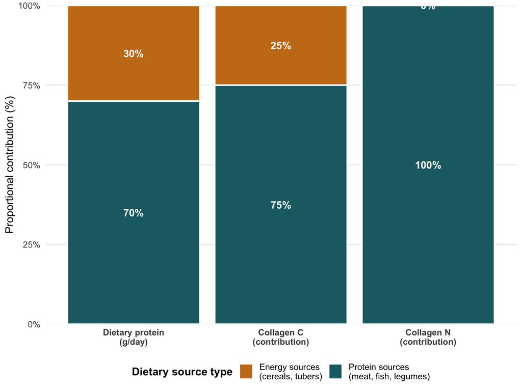

# 5 ReSources Workflow: A Practical Example

## 5.1 Dataset: Late Medieval Urban Population

We will reconstruct the diet of individuals from a late medieval urban cemetery using bone collagen isotope values and archaeological/historical evidence for available food sources.

### 5.1.1 Consumer Data

Ten adult individuals with bone collagen measurements:

Table 2: Consumer isotope data (example subset)

| Individual | δ¹³C (‰) | δ¹⁵N (‰) | Context |
| --- | --- | --- | --- |
| Burial 12 | −19.8 ± 0.2 | +10.5 ± 0.3 | High-status grave |
| Burial 23 | −20.1 ± 0.2 | +9.8 ± 0.3 | Common burial |
| Burial 34 | −19.5 ± 0.2 | +11.2 ± 0.3 | Monastic context |
| … | … | … | … |

### 5.1.2 Dietary Source Data

Based on zooarchaeological remains and regional paleobotanical evidence:

**Protein sources:**

Table 3: Protein source end-members

| Source | δ¹³C (‰) | δ¹⁵N (‰) | %Protein | Evidence |
| --- | --- | --- | --- | --- |
| Terrestrial meat (cattle, sheep, pig) | −21.3 ± 0.7 | +6.8 ± 1.1 | 20% | Faunal assemblage (n = 45) |
| Freshwater fish | −24.2 ± 1.3 | +12.5 ± 1.6 | 18% | Fish bones (n = 12) |
| Marine fish (cod, herring) | −14.8 ± 0.9 | +14.2 ± 1.4 | 19% | Imported; historical records |
| Legumes (peas, beans) | −26.1 ± 1.0 | +2.5 ± 1.5 | 25% | Charred seeds (n = 23) |

**Energy sources:**

Table 4: Energy source end-members

| Source | δ¹³C (‰) | %Calories | Evidence |
| --- | --- | --- | --- |
| C<sub>3</sub> cereals (wheat, barley) | −25.8 ± 0.9 | — | Charred grain (n = 67) |
| Dairy products | −22.0 ± 1.2 | — | Historical records; lipid residues |

### 5.1.3 TEF Values

From literature (O’Connell et al. 2012; Styring et al. 2010):

- Δ<sup>13</sup>C (protein-routed): +1.0 ± 0.3 ‰
- Δ<sup>13</sup>C (energy-routed): +0.5 ± 0.5 ‰
- Δ<sup>15</sup>N: +4.0 ± 1.0 ‰
- Routing parameter λ: 0.74 ± 0.08 (from controlled diet studies)

## 5.2 Step-by-Step ReSources Analysis

### 5.2.1 Step 1: Prepare Input Data

ReSources requires three data files (CSV format):

1. **consumers.csv** — one row per individual, columns: ID, d13C_mean, d13C_sd, d15N_mean, d15N_sd
2. **sources_protein.csv** — protein source end-members with isotope values and protein content
3. **sources_energy.csv** — energy source end-members with isotope values

Example `consumers.csv`:

```
ID,d13C_mean,d13C_sd,d15N_mean,d15N_sd
Burial_12,-19.8,0.2,10.5,0.3
Burial_23,-20.1,0.2,9.8,0.3
Burial_34,-19.5,0.2,11.2,0.3
```

Example `sources_protein.csv`:

```
source,d13C_mean,d13C_sd,d15N_mean,d15N_sd,protein_content
Terrestrial_meat,-21.3,0.7,6.8,1.1,20
Freshwater_fish,-24.2,1.3,12.5,1.6,18
Marine_fish,-14.8,0.9,14.2,1.4,19
Legumes,-26.1,1.0,2.5,1.5,25
```

### 5.2.2 Step 2: Run ReSources in R

```r
library(ReSources)

# Load data
consumers <- read.csv("consumers.csv")
proteins  <- read.csv("sources_protein.csv")
energy    <- read.csv("sources_energy.csv")

# Define TEF priors
tef_protein_C <- c(mean = 1.0, sd = 0.3)
tef_energy_C  <- c(mean = 0.5, sd = 0.5)
tef_N         <- c(mean = 4.0, sd = 1.0)
routing_lambda <- c(mean = 0.74, sd = 0.08)

# Run the model (MCMC)
results <- run_ReSources(
  consumers = consumers,
  sources_protein = proteins,
  sources_energy = energy,
  tef_protein_C = tef_protein_C,
  tef_energy_C = tef_energy_C,
  tef_N = tef_N,
  routing_lambda = routing_lambda,
  n_iter = 50000,
  n_burnin = 10000,
  n_chains = 3,
  n_thin = 5
)

# Check convergence
check_convergence(results)  # Gelman-Rubin statistic should be < 1.1

# Extract posterior summaries
summary(results)
```

### 5.2.3 Step 3: Interpret Results

ReSources returns posterior distributions for:

1. **Protein source contributions** ($p_i$) — what proportion of dietary **protein** came from each source
2. **Energy source contributions** ($e_j$) — what proportion of dietary **energy** came from each source
3. **Convergence diagnostics** — Gelman-Rubin $\hat{R}$, effective sample size

Example output for Burial 12 (high-status):

[output not shown]

Table 5: Example ReSources output for high-status burial

| Energy source | Median | 95% CI |
| --- | --- | --- |
| C<sub>3</sub> cereals | 0.68 | [0.52, 0.82] |
| Dairy products | 0.32 | [0.18, 0.48] |

# 6 Visualising ReSources Outputs

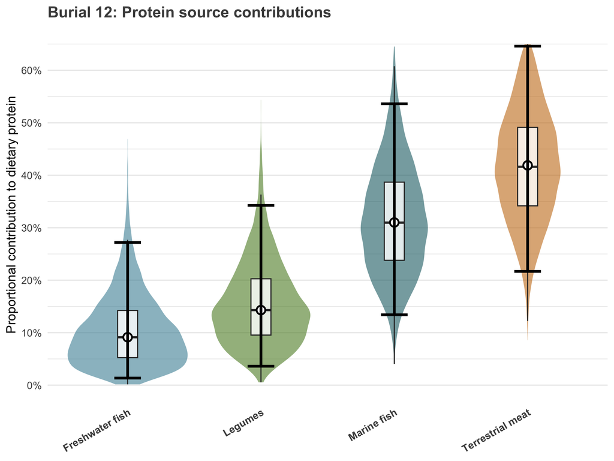

Figure 2: Posterior distributions for protein source contributions (Burial 12). Violin plots show the full Bayesian posterior; thick black lines mark the median and 95% credible intervals. Wide posteriors indicate high uncertainty.

```r
# Simulate ReSources posterior output for demonstration
set.seed(2024)
n_samples <- 5000

# Generate realistic MCMC samples using Dirichlet distribution
library(MCMCpack)

# Protein sources: moderately informative (high meat, moderate marine, low fish/legumes)
protein_samples <- rdirichlet(n_samples, alpha = c(8, 2, 6, 3))
colnames(protein_samples) <- c("Terrestrial meat", "Freshwater fish",
                                "Marine fish", "Legumes")

# Convert to long format for plotting
protein_long <- as.data.frame(protein_samples) %>%
  mutate(iteration = 1:n()) %>%
  pivot_longer(cols = -iteration, names_to = "source", values_to = "proportion")

# Calculate summary statistics
protein_summary <- protein_long %>%
  group_by(source) %>%
  summarise(
    median = median(proportion),
    q025 = quantile(proportion, 0.025),
    q975 = quantile(proportion, 0.975),
    .groups = "drop"
  )

ggplot(protein_long, aes(x = source, y = proportion, fill = source)) +
  geom_violin(alpha = 0.6, colour = NA) +
  geom_boxplot(width = 0.15, outlier.shape = NA,
               fill = "white", alpha = 0.8) +
  geom_point(data = protein_summary, aes(y = median),
             size = 3, shape = 21, fill = "white", colour = "black", stroke = 1.2) +
  geom_errorbar(data = protein_summary,
                aes(y = median, ymin = q025, ymax = q975),
                width = 0.2, linewidth = 1.2, colour = "black") +
  scale_fill_manual(values = c(
    "Terrestrial meat" = col_amber,
    "Freshwater fish" = "#4A90A4",
    "Marine fish" = col_teal,
    "Legumes" = "#5B8A2D"
  )) +
  scale_y_continuous(labels = scales::percent_format(),
                     breaks = seq(0, 0.6, 0.1),
                     limits = c(0, 0.65)) +
  labs(
    title = "Burial 12: Protein source contributions",
    x = NULL,
    y = "Proportional contribution to dietary protein"
  ) +
  theme_minimal(base_size = 12) +
  theme(
    legend.position = "none",
    axis.text.x = element_text(angle = 30, hjust = 1, colour = col_grey, face = "bold"),
    plot.title = element_text(face = "bold", hjust = 0, colour = col_grey),
    panel.grid.major.x = element_blank(),
    plot.background = element_rect(fill = "white", colour = NA)
  )
```

**Reading Bayesian posteriors**

- **Median** (white point) = most probable value
- **95% CI** (thick black line) = range containing 95% of plausible values
- **Violin width** = probability density (fatter = more likely)

Wide credible intervals indicate high uncertainty — this is honest reporting, not model failure.

# 7 Limitations and Assumptions

Even sophisticated Bayesian routed models like ReSources cannot overcome fundamental data limitations. Understanding these constraints is essential for responsible interpretation.

## 7.1 Assumption 1: All Sources Are Known and Measured

The mixing model assumes that the **complete set of dietary sources** has been identified and isotopically characterised.

**The “unknown unknowns” problem**

If you omit a source that contributed 20% of dietary protein, the model will spuriously inflate the estimated contributions of the included sources. There is no statistical test for this — it requires archaeological and zooarchaeological expertise.

**Checklist before running ReSources:**  
☐ Faunal reference collection from the same site/period  
☐ Botanically identified plant macrofossils with isotope measurements  
☐ Evidence ruling out major unlisted sources (e.g., C<sub>4</sub> plants, marine mammals)

## 7.2 Assumption 2: Sources Are Isotopically Distinct

If two protein sources have overlapping isotope values, the model cannot reliably distinguish them — this is the problem of **source confounding**.

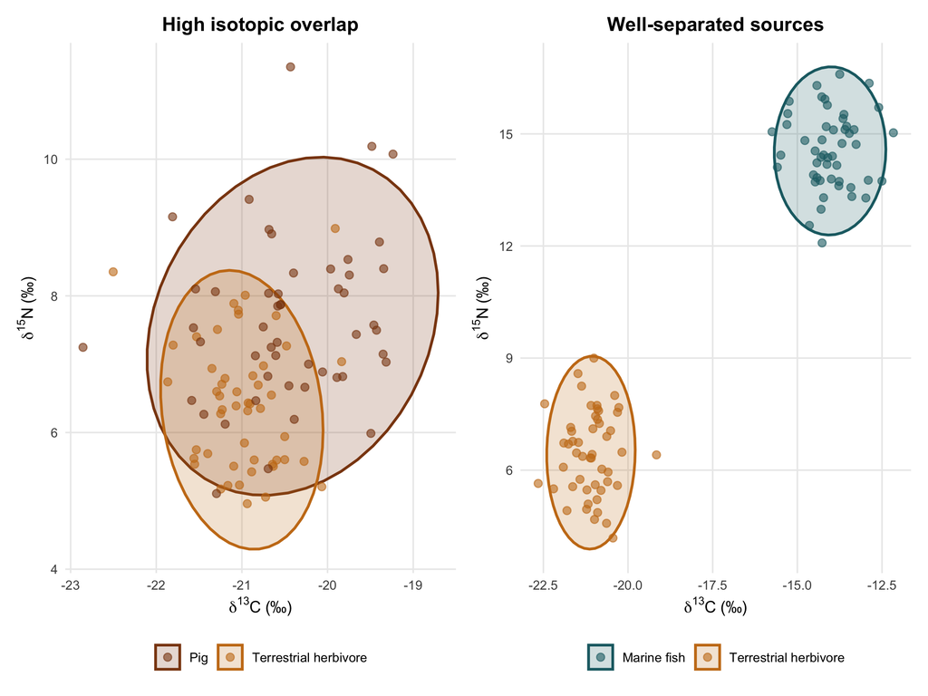

Figure 3: Isotopic overlap between dietary sources. When source ellipses overlap substantially (left), dietary proportions are poorly constrained. Well-separated sources (right) produce tighter Bayesian posteriors.

```r
library(ggforce)

# Define two scenarios
high_overlap <- tibble(
  source = rep(c("Terrestrial herbivore", "Pig"), each = 50),
  d13C = c(rnorm(50, -21.0, 0.6), rnorm(50, -20.5, 0.9)),
  d15N = c(rnorm(50, 6.5, 0.9), rnorm(50, 7.8, 1.2))
)

well_separated <- tibble(
  source = rep(c("Terrestrial herbivore", "Marine fish"), each = 50),
  d13C = c(rnorm(50, -21.0, 0.6), rnorm(50, -14.0, 0.8)),
  d15N = c(rnorm(50, 6.5, 0.9), rnorm(50, 14.5, 1.1))
)

plot_overlap <- function(data, title) {
  ggplot(data, aes(x = d13C, y = d15N, colour = source, fill = source)) +
    stat_ellipse(geom = "polygon", level = 0.95, alpha = 0.2, linewidth = 0.8) +
    geom_point(size = 2, alpha = 0.6) +
    scale_colour_manual(values = c(
      "Terrestrial herbivore" = col_amber,
      "Pig" = "#8B4513",
      "Marine fish" = col_teal
    )) +
    scale_fill_manual(values = c(
      "Terrestrial herbivore" = col_amber,
      "Pig" = "#8B4513",
      "Marine fish" = col_teal
    )) +
    labs(
      title = title,
      x = expression(delta^13*C~"(‰)"),
      y = expression(delta^15*N~"(‰)")
    ) +
    theme_minimal(base_size = 10) +
    theme(
      legend.position = "bottom",
      legend.title = element_blank(),
      panel.grid.minor = element_blank(),
      plot.title = element_text(face = "bold", hjust = 0.5),
      plot.background = element_rect(fill = "white", colour = NA)
    )
}

library(patchwork)
plot_overlap(high_overlap, "High isotopic overlap") +
  plot_overlap(well_separated, "Well-separated sources")
```

**Solutions when sources overlap:**

1. Add a third isotope tracer (e.g., δ<sup>34</sup>S from marine vs. terrestrial sulphur sources)
2. Pool similar sources into a single combined end-member (e.g., “Terrestrial herbivores” = sheep + cattle + pig)
3. Use informative Bayesian priors based on zooarchaeological abundance data

## 7.3 Assumption 3: Routing Parameter (λ) Is Known

The routing parameter λ quantifies the proportion of collagen carbon derived from dietary protein. ReSources requires a prior distribution for λ, typically derived from controlled feeding experiments:

- **Human adults:** λ = 0.74 ± 0.08 (Fernandes et al. 2012)
- **Omnivores (pigs):** λ = 0.76 ± 0.07
- **Carnivores:** λ ≈ 0.85 (higher protein diet → stronger routing)

**Sensitivity to λ**

The routing parameter has a large effect on estimated dietary proportions. Always conduct **sensitivity analyses** with alternative λ values (e.g., 0.70, 0.74, 0.80) and report the range of plausible results.

## 7.4 Problem 4: Equifinality (Non-Unique Solutions)

**Equifinality** occurs when multiple combinations of sources produce similar consumer isotope values. This is an inherent property of underdetermined systems and cannot be “solved” by more sophisticated statistics.

### 7.4.1 Example: Three Protein Sources with Similar δ¹³C

Suppose three protein sources all have δ<sup>13</sup>C ≈ −21 ‰ but different δ<sup>15</sup>N:

| Source | δ¹³C (‰) | δ¹⁵N (‰) |
| --- | --- | --- |
| Sheep | −21.2 | +6.0 |
| Cattle | −20.8 | +7.0 |
| Pig | −21.5 | +8.5 |

A consumer with δ<sup>13</sup>C = −20.2 ‰, δ<sup>15</sup>N = +10.8 ‰ could have consumed:

- **Solution A:** 60% sheep, 20% cattle, 20% pig
- **Solution B:** 20% sheep, 60% cattle, 20% pig
- **Solution C:** 20% sheep, 20% cattle, 60% pig

**ReSources handles this by:** reporting very wide posterior credible intervals for all three sources, honestly reflecting the uncertainty. Some users mistakenly interpret wide posteriors as “model failure” — they are actually correct quantification of irreducible uncertainty.

## 7.5 Problem 5: Sample Size Effects

### 7.5.1 Source Reference Specimens

Minimum sample sizes for reliable source characterisation:

Table 6: Recommended sample sizes for source end-members

| Source type | Minimum n | Target n | Rationale |
| --- | --- | --- | --- |
| Domesticated animals (low variability) | 5 | 10–15 | Stable husbandry practices |
| Wild animals (high variability) | 10 | 15–20 | Dietary plasticity; habitat variation |
| Fish (very high variability) | 15 | 20–30 | Ontogenetic shifts; migration |
| Plants (moderate variability) | 10 | 15–20 | Soil nitrogen heterogeneity |

### 7.5.2 Consumer Sample Sizes for Group Comparisons

When comparing dietary proportions between groups (e.g., high vs. low status; male vs. female), statistical power depends on:

1. Effect size — how different are the groups?
2. Within-group variability — do all individuals in a status group eat similarly?
3. Source separation — well-separated sources require smaller n

**Rule of thumb:** n ≥ 10 per group for exploratory analyses; n ≥ 20 per group for publication-quality comparisons.

# 8 ReSources vs. Other Bayesian Models

Table 7: Comparison of major mixing model software

| Model | Routing | Framework | Priors | Key use case |
| --- | --- | --- | --- | --- |
| **ReSources** | ✓ Protein/energy | JAGS (Bayesian) | Flexible | **Archaeological bone collagen** (preferred) |
| **FRUITS** | ✓ Protein/energy | WinBUGS (Bayesian) | Flexible | Bone collagen; slower than ReSources |
| **MixSIAR** | ✗ Bulk diet | JAGS (Bayesian) | Flexible | Ecology; not ideal for collagen |
| **SIAR** | ✗ Bulk diet | WinBUGS (Bayesian) | Uninformative only | Legacy; superseded by MixSIAR |
| **IsoSource** | ✗ Bulk diet | Linear (deterministic) | None | Teaching; fast exploratory analysis |

**When to use ReSources**

Use ReSources when:

✓ Your tissue is **bone or dentine collagen**  
✓ You need to distinguish **protein vs. energy source contributions**  
✓ You have reliable estimates for the routing parameter λ  
✓ You want to incorporate zooarchaeological priors on source availability

Use MixSIAR instead if analyzing muscle tissue, blood, or other tissues where routing is less pronounced.

# 9 Learning Outcomes Checklist

By the end of this session you should be able to:

1. Distinguish simple linear mixing models from Bayesian routed models, and explain why routing matters for collagen-based dietary reconstruction (Section 2).
2. Write down the routed mixing model equation for bone collagen δ<sup>13</sup>C (Equation 1) and explain the role of the routing parameter λ.
3. Explain why unrouted models (SIAR, early MixSIAR) can produce biased dietary estimates when applied to bone collagen data.
4. Describe the ReSources workflow: data preparation, MCMC execution via JAGS, convergence checking, and posterior interpretation (Section 5).
5. Interpret Bayesian posterior distributions: median, 95% credible intervals, and the meaning of wide vs. narrow posteriors.
6. Critically evaluate whether a mixing model is valid for a given dataset by checking: (a) are all sources known? (b) are sources isotopically distinct? (c) is the routing parameter appropriate? (Section 7).
7. Define equifinality and explain why overlapping sources produce wide, multimodal posteriors even with perfect data (Section 7.4).
8. State minimum recommended sample sizes for source reference specimens (n ≥ 10–15 for most taxa) and consumer groups (n ≥ 10 exploratory, n ≥ 20 for robust comparisons) (Section 7.5).

# 10 Key Equations Reference

### 10.0.1 Routed mixing model for bone collagen δ¹³C

$$\delta^{13}C_{\text{collagen}} = \lambda \cdot \left[ \sum_{i} p_i \cdot (\delta^{13}C_{i,\text{protein}} + \Delta^{13}C_p) \right] + (1 - \lambda) \cdot \left[ \sum_{j} e_j \cdot (\delta^{13}C_{j,\text{energy}} + \Delta^{13}C_e) \right]$$

### 10.0.2 Nitrogen equation (protein-routed)

$$\delta^{15}N_{\text{collagen}} = \sum_{i} p_i \cdot (\delta^{15}N_{i,\text{protein}} + \Delta^{15}N)$$

### 10.0.3 Constraints

$$\sum_{i} p_i = 1, \quad \sum_{j} e_j = 1, \quad p_i \geq 0, \quad e_j \geq 0, \quad 0.5 \leq \lambda \leq 1.0$$

**Typical parameter values:**

- λ (routing, humans): 0.74 ± 0.08
- Δ<sup>13</sup>C<sub>protein</sub>: +1.0 ± 0.3 ‰
- Δ<sup>13</sup>C<sub>energy</sub>: +0.5 ± 0.5 ‰
- Δ<sup>15</sup>N: +4.0 ± 1.0 ‰

# 11 Recommended Further Reading

**On ReSources:**

Fernandes, R., Millard, A.R., Brabec, M., Nadeau, M.-J. & Grootes, P. (2014) Food reconstruction using isotopic transferred signals (FRUITS): a Bayesian model for diet reconstruction. *PLoS ONE*, **9**, e87436. [Introduces the routed mixing model concept]

Fernandes, R., Bataille, C.P., Rasigraf, O., Raghavan, M. & Mallick, R. (2021) Assessing the use of bulk stable isotope data in zooarchaeology. *Science Advances*, **7**, eabg5791. [**The definitive ReSources paper** — includes validation, case studies, comparison with FRUITS]

**On isotopic routing:**

Ambrose, S.H. & Norr, L. (1993) Experimental evidence for the relationship of the carbon isotope ratios of whole diet and dietary protein to those of bone collagen and carbonate. In: Lambert & Grupe (eds), *Prehistoric Human Bone*, pp. 1–37. [Foundational controlled-diet experiments]

Jim, S., Jones, V., Ambrose, S.H. & Evershed, R.P. (2006) Quantifying dietary macronutrient sources of carbon for bone collagen biosynthesis using natural abundance stable carbon isotope analysis. *British Journal of Nutrition*, **95**, 1055–1062. [Further experimental validation of routing]

**On Bayesian mixing models (for context):**

Parnell, A.C., Inger, R., Bearhop, S. & Jackson, A.L. (2010) Source partitioning using stable isotopes: coping with too much variation. *PLoS ONE*, **5**, e9672. [Introduces SIAR; clear explanation of Bayesian framework]

Stock, B.C. & Semmens, B.X. (2016) MixSIAR GUI User Manual. Version 3.1. [Comprehensive MixSIAR documentation; useful for understanding Bayesian mixing models generally]

Phillips, D.L., Inger, R., Bearhop, S., Jackson, A.L., Moore, J.W., Parnell, A.C., Semmens, B.X. & Ward, E.J. (2014) Best practices for use of stable isotope mixing models in food-web studies. *Canadian Journal of Zoology*, **92**, 823–835. [Essential reading on common pitfalls and best practices]

*End of Module 2 — coffee break 10:30–10:45, then continue to Module 3: Bayesian Frameworks in Practice (10:45–12:00)*